# Problem Set 06

WRITE YOUR NAME HERE

Due Friday, October 28, 2016

## Question: `nycflights13` data

```r
# Load all pacakges necessary
library(ggplot2)
library(dplyr)
library(knitr)

# Load all data sets in nycflights
library(nycflights13)
data(flights)
data(planes)
data(airlines)
data(weather)
data(airports)
```

You are a junior analyst in the airline industry, specifically working for Virgin America. You are tasked with calculating Virgin America’s total [available seat miles](https://en.wikipedia.org/wiki/Available_seat_miles) for all flights leaving each of the three New York Metropolitan area airports separately, and comparing these figures with those of ExpressJet Airlines Inc, a close rival to your company. Available seat miles are the fundamental units of production for a passenger-carrying airline and it is a measure of capacity. You are asked for two deliverables:

1. Present these results in
   - A well-formatted and easy to read table
   - A cleanly formatted visualization
2. Give a two sentence executive summary on the comparison in available seat miles between Virgin America and ExpressJet Airlines Inc for the three NYC airports.

## Tips

Two tips for working smarter:

1. Defining your target
2. Cleaning up your workspace

#### 1. Define your target

You should at least mentally, if not explicitly on a piece of paper or black/whiteboard, know what your end data frame should look like **in tidy format**:

- How many columns and what are their names i.e. the variables
- How many rows will I have?
- Fill in elements of the table the best you can.

If you don’t have a plan, not only will your work not be focused, but more importantly, how would you know when you’re done? In our case since we are comparing capacity (as measured by available seat miles) at the three airports for Virgin America and ExpressJet, we know before even typing a single line of code, our end table should look something like this:

| Airport | Airlines | Available Seat Miles |
| --- | --- | --- |
| JFK | VX | some value |
| JFK | EV | some value |
| EWR | VX | some value |
| EWR | EV | some value |
| LGA | VX | some value |
| LGA | EV | some value |

**Advanced**: Annie pointed out that a table like this would work too:

| Airport | VX Available Seat Miles | EV Available Seat Miles |
| --- | --- | --- |
| JFK | some value | some value |
| EWR | some value | some value |
| EWR | some value | some value |

But note this is not in tidy data format (i.e. long format), but in wide format. For `ggplot2` and `dplyr` to work, we need to be consistent about the data format: only tidy format. If you do want to switch from tidy/long to wide format or vice versa, you can use the `tidyr` package: see the `dplyr` cheatsheet, front page, “Reshaping Data” section, `gather()` and `spread()` functions. This is for a more advanced class however.

#### 2. Clean up your workspace

Before doing any kind of complex `mutate`, `summarise`, `arrange`, or `_join`, I like to pare down the necessary data sets to the minimum of what I need by

- `select` only the absolutely neccesary columns
- `filter` only the absolutely necessary rows

This has several benefits:

1. It will make it much easier to digest `View()`s of your work as you progress.
2. It will minimize the chance of weird errors creeping in.
3. **Most importantly**: It will force you to think
   - “What variables do I need?” and hence
   - “Where are they located?” and hence
   - “What data sets do I need?”

In our case, we are going to need the following variables:

- `carrier` and `origin` for the end table, both in the `flights` data set
- `distance` and `seats` to compute `total_seat_miles`, with `seats` being in the `planes` data set
- `tailnum` to be able to join/merge `flights` and `planes`

## Deliverable 1: Table

```r
# Clean up our workspace: Reduce both the flights and planes data sets to only
# those columns and rows we need.
flights_cleaned <- flights %>%
  filter(carrier == "VX" | carrier == "EV") %>%
  select(tailnum, carrier, distance, origin)

planes_cleaned <- planes %>%
  select(tailnum, seats)

# Now we join the two by the variable "tailnum". Note, when the variable we are
# joining along has the same name in both datasets, we don't need to do:
# by = c("tailnum" = "tailnum")
flights_planes_joined <- flights_cleaned %>%
  left_join(planes_cleaned, by = "tailnum")

results <- flights_planes_joined %>%
  # Now we can compute ASM:
  mutate(seat_miles = seats * distance) %>%
  # Since we want all 6 possible origin X carrier pairs, we group by
  # those variables and THEN summarize
  group_by(origin, carrier) %>%
  summarise(total_seat_miles = sum(seat_miles)) %>%
  # While not necessary, I decide to sort in descending order of ASM
  arrange(desc(total_seat_miles))

# Use the kable() function from the knitr package to print the output cleanly
kable(results)
```

| origin | carrier | total_seat_miles |
| --- | --- | --- |
| JFK | VX | 1632349744 |
| EWR | EV | 1465958750 |
| EWR | VX | 664331034 |
| LGA | EV | 333516285 |
| JFK | EV | 17761240 |

## Deliverable 2: Visualization

Now when it comes to plotting, recall me email from Thursday, Oct 27 referencing how to plot a `geom_bar()` when you have an explicit variable you want to map to the `y` aesthetic. You need to tell `geom_bar()` to override its default behavior and use the `y=total_seat_miles` variable by setting `geom_bar(stat="identity")`. See the code for Problem Set 05 Discussion -> Q1.c) -> second plot comparing proportions for another example.

**Note**: We don’t forget the axes labels and title!

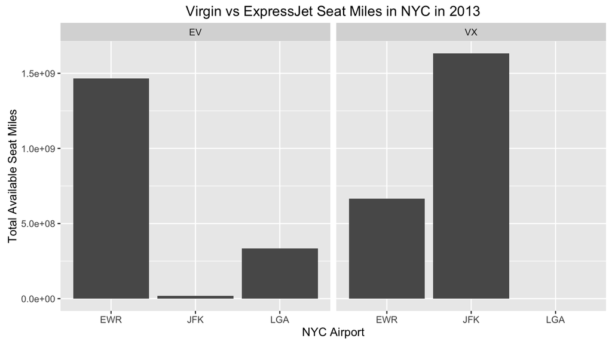

```r
ggplot(results, aes(x=origin, y=total_seat_miles)) +
  geom_bar(stat="identity") +
  facet_wrap(~carrier) +
  labs(x="NYC Airport", y="Total Available Seat Miles", title="Virgin vs ExpressJet Seat Miles in NYC in 2013")
```

My executive summary: Overall, we (as in Virgin America) have about the same capacity, but definitely spread out over different airports. We’ve got JFK covered, but definitely don’t have the capacity that ExpressJet does at Newark and La Guardia. So I suggest we target our marketing so that

- we promote our great number of options to people who tend to fly out of JFK.
- we start running ads that bad mouth ExpressJet to people who tend to fly out of Newark.

## Advanced

Once you get better at these things, you can write code super consisely. Not required for this class…

```r
flights %>%
  left_join(planes, by = "tailnum") %>%
  filter(carrier %in% c("VX", "EV")) %>%
  mutate(seat_miles = seats*distance) %>%
  group_by(origin, carrier) %>%
  summarise(total_seat_miles = sum(seat_miles)) %>%
  arrange(desc(total_seat_miles)) %>%
  kable()
```

| origin | carrier | total_seat_miles |
| --- | --- | --- |
| JFK | VX | 1632349744 |
| EWR | EV | 1465958750 |
| EWR | VX | 664331034 |
| LGA | EV | 333516285 |
| JFK | EV | 17761240 |